# Extract Taxa list from SARCE country data

## Introduction

This script will read SARCE data and extract the list of taxa. The extracted list will be matched against WoRMS and the corrections made. The SARCE dataset is already split by country.

## Read the data

The SARCE dataset in full is a table in wide format, with the taxon name in the columns along with many other variables identifying the site. We will produce a table in long format with the taxon name in the column “scientificName” (standard DwC name). As this table is only presence/absence we will recode that in the “occurrence” variable.

```r
library(tidyr)
library(readr)  ## this one is better for reading the wide-table

## I'll use Venezuela as case study here
## read the data
VEN <- read_csv("data/SARCE/Venezuela.csv")
## see the tablel dimensions
dim(VEN)
```

```
## [1]  620 1136
```

## Clean the data

You see that the Venezuela SARCE table has 620 rows and 1136 columns.

**TIP**: in RStudio, if you have a very wide table (i.e. many columns) don’t try to view the table in the viewer as it will take very long time to accommodate all the columns in the memory

Now, let extract the names of the taxa in the table. In the SARCE table, the first two columns are identification values, then the taxon name are in columns 3:1113. The rest of the columns are variables associated with the site (lat, lon, depth, zone, etc). More on those columns later…

So lets use `tidyr::gather` to convert the table from wide to long format

```r
VEN.long = gather(VEN, key=scientificName, value=occurrence, 3:1113)

## look at the structure
str(VEN.long)
```

```
## Classes 'tbl_df', 'tbl' and 'data.frame':    688820 obs. of  27 variables:
##  $ Id            : chr  "Ve-Mi-Chi-Cor-L1" "Ve-Mi-Chi-Cor-L2" "Ve-Mi-Chi-Cor-L3" "Ve-Mi-Chi-Cor-L4" ...
##  $ pathString    : chr  "Ve/Mi/Chi/Cor/L1" "Ve/Mi/Chi/Cor/L2" "Ve/Mi/Chi/Cor/L3" "Ve/Mi/Chi/Cor/L4" ...
##  $ Year          : int  2010 2010 2010 2010 2010 2010 2010 2010 2010 2010 ...
##  $ Months        : int  7 7 7 7 7 7 7 7 7 7 ...
##  $ Country       : chr  "Venezuela" "Venezuela" "Venezuela" "Venezuela" ...
##  $ Country_code  : chr  "Ve" "Ve" "Ve" "Ve" ...
##  $ State         : chr  "Miranda" "Miranda" "Miranda" "Miranda" ...
##  $ State_code    : chr  "Mi" "Mi" "Mi" "Mi" ...
##  $ Locality      : chr  "Chirimena" "Chirimena" "Chirimena" "Chirimena" ...
##  $ Locality_code : chr  "Chi" "Chi" "Chi" "Chi" ...
##  $ Site          : chr  "Corrales" "Corrales" "Corrales" "Corrales" ...
##  $ Site_code     : chr  "Cor" "Cor" "Cor" "Cor" ...
##  $ Strata        : chr  "Lowtide" "Lowtide" "Lowtide" "Lowtide" ...
##  $ Strata_code   : chr  "L" "L" "L" "L" ...
##  $ Sampling Date : chr  "07/30/14" "07/30/14" "07/30/14" "07/30/14" ...
##  $ Observers     : chr  "JJ_Cruz/C_Herrera/A_Hernandez/N_Fernandez" "JJ_Cruz/C_Herrera/A_Hernandez/N_Fernandez" "JJ_Cruz/C_Herrera/A_Hernandez/N_Fernandez" "JJ_Cruz/C_Herrera/A_Hernandez/N_Fernandez" ...
##  $ Picture number: chr  "IMG_3308" "IMG_3309" "IMG_3310" "IMG_3311" ...
##  $ Replicate     : int  1 2 3 4 5 6 7 8 9 10 ...
##  $ Labelscopy    : chr  "Ve-Mi-Chi-Cor-L1" "Ve-Mi-Chi-Cor-L2" "Ve-Mi-Chi-Cor-L3" "Ve-Mi-Chi-Cor-L4" ...
##  $ Si-Strata     : chr  "Cor-Lowtide" "Cor-Lowtide" "Cor-Lowtide" "Cor-Lowtide" ...
##  $ BioR          : int  66 66 66 66 66 66 66 66 66 66 ...
##  $ Latitude      : num  10.6 10.6 10.6 10.6 10.6 ...
##  $ Bioregion     : chr  "South_caribbean" "South_caribbean" "South_caribbean" "South_caribbean" ...
##  $ Ocean         : chr  "Atlantic" "Atlantic" "Atlantic" "Atlantic" ...
##  $ Zone          : chr  "Tropics" "Tropics" "Tropics" "Tropics" ...
##  $ scientificName: chr  "Abiota" "Abiota" "Abiota" "Abiota" ...
##  $ occurrence    : chr  NA NA NA NA ...
```

We need to do some cleaning. The taxon name is separated by an underscore. we want a space (for WoRMS to process the match). We don’t need lines with `occurrence` equal to NA (that means that this particular taxon was not observed) nor the taxon “Abiotic”

```r
## remote the lines with occurrence == NA
VEN.long = VEN.long[!is.na(VEN.long$occurrence),]

## remote the lines with taxa "abiotic"
VEN.long = VEN.long[VEN.long$scientificName!="Abiota",]

## replace the underscore in the taxon name by a space
VEN.long$scientificName = gsub("_", " ", VEN.long$scientificName)
```

## Extract the taxa list

Now with the date clean, let extract the taxon list, and save it in a text file for matching with WoRMS

```r
taxa = unique(VEN.long$scientificName)
print(taxa)
```

```
##   [1] "Acanthophora spicifera"    "Acanthopleura granulata"
##   [3] "Acmaea antillarum"         "Acmaea sp1"
##   [5] "Acmaea sp2"                "Acmaea sp4"
##   [7] "Actiniaria spp1"           "Agaricia agaricites"
##   [9] "Amphiroa fragilissima"     "Amphiroa sp1"
##  [11] "Aplysia dactylomela"       "Ascidiidae spp"
##  [13] "Asparagopsis sp1"          "Asparagopsis sp2"
##  [15] "Asparagopsis sp3"          "Astraea sp1"
##  [17] "Astraea tecta"             "Balanus sp2"
##  [19] "Bivalvia spp"              "Brachidontes dominguensis"
##  [21] "Brachidontes sp1"          "Brachidontes sp2"
##  [23] "Brachidontes sp3"          "Brachidontes sp4"
##  [25] "Brachidontes sp5"          "Brachidontes sp6"
##  [27] "Brachidontes sp7"          "Bryopsis pennata"
##  [29] "Bryopsis plumosa"          "Bryopsis sp1"
```

[output cut: 94 more lines]

```r
## save it in a text file
writeLines(unique(VEN.long$scientificName), con="data/SARCE/VEN_taxa.csv")
```

## Frequency of Taxa

Lets make a simple plot of the frequency of each taxa. But remember that this is not the final taxa list: it must be checked before with WoRMS

In this case I’ll use the basic plotting system of R and a bar plot. But you can use `ggplot2` package which is much more configurable and produces publication quality plots

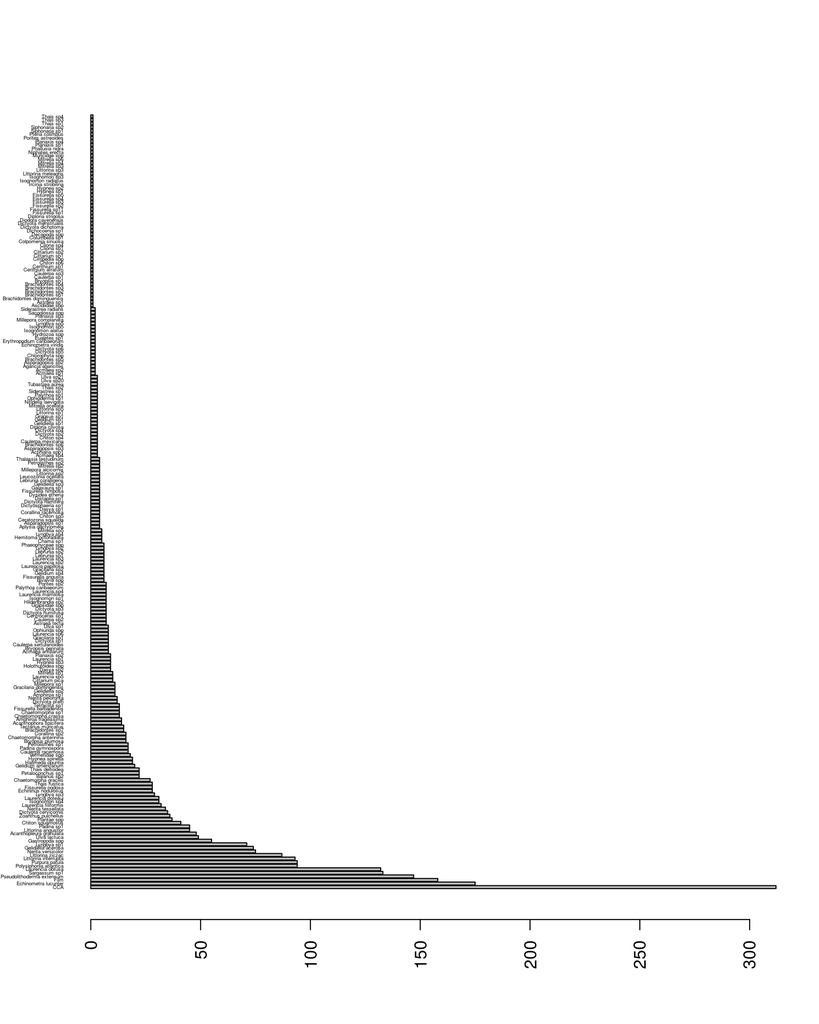

```r
## first make a table of frequencies
taxafreq = table(VEN.long$scientificName)

## make a basic horizontal barplot
barplot(sort(taxafreq, decreasing = T), las=2, cex.names=0.3, horiz = T)
```

But this plot has all the taxa and makes the labels unreadable. Let say that we’re more interested in the taxa that represent the 75% of all occurrences

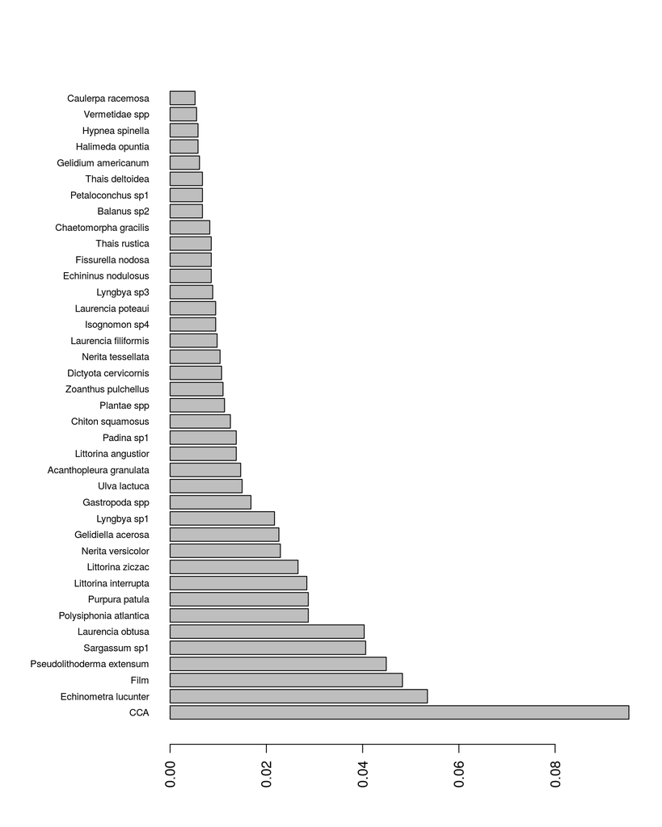

```r
## Make a table of proportions
taxafreq.prop = prop.table(taxafreq)

## convert the table into a data frame
taxafrec.df = as.data.frame(taxafreq.prop)

## sort the table by proportion (descending)
taxafrec.df = taxafrec.df[order(taxafrec.df$Freq, decreasing = T),]

## add the accum freq
taxafrec.df$Freq.accum = cumsum(taxafrec.df$Freq)

## plot the taxa for 75% of all occurrences
## first look at the indices of the taxa accummulats up to 75% and pick the first index
limit75 = which(taxafrec.df$Freq.accum>0.75)[1]

## do the plot with the reduced data frame
## note that this time we will be plotting a data frame not a table like the previous plot
## change the margins to accomodate long labels
par(mar=c(5,10,4,2))
## make the plot
barplot(taxafrec.df$Freq[1:limit75], names.arg = taxafrec.df$Var1[1:limit75],  las=2, cex.names=0.7, horiz = T)
```

You see in this data set “Film”, and “CCA” are main components. You probably won’t need it. Also many taxa are not fully identified at species level. WoRMS could help you to correct and homogenize your taxon list.

Now got to WoRMS and do the match